# Week 2 Reproducible Research RMD format

Wong Hui Shin

August 30, 2020

## R Markdown

This is the Markdown of documentation on the daily activity pattern.

## Loading and preprocessing the data

1. Code for reading in the dataset and/or processing the data

```r
week2 = read.csv("activity.csv")
str(week2)
```

```
## 'data.frame':    17568 obs. of  3 variables:
##  $ steps   : int  NA NA NA NA NA NA NA NA NA NA ...
##  $ date    : chr  "2012-10-01" "2012-10-01" "2012-10-01" "2012-10-01" ...
##  $ interval: int  0 5 10 15 20 25 30 35 40 45 ...
```

```r
library(ggplot2)
```

## What is mean total number of steps taken per day?

2. Histogram of the total number of steps taken each day

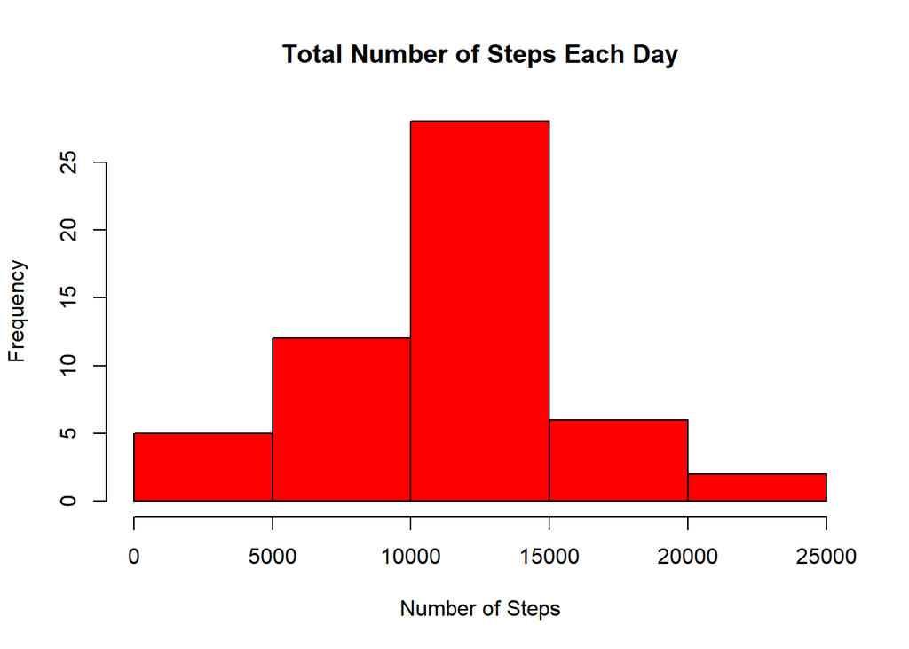

```r
steps_by_day <- aggregate(steps ~ date, week2, sum)
hist(steps_by_day$steps, main = ("Total Number of Steps Each Day"), col="red",xlab="Number of Steps")
```

3. Mean and median number of steps taken each day

```r
rmean <- mean(steps_by_day$steps)
rmean
```

```
## [1] 10766.19
```

```r
rmedian <- median(steps_by_day$steps)
rmedian
```

```
## [1] 10765
```

## What is the average daily activity pattern?

4. Time series plot of the average number of steps taken

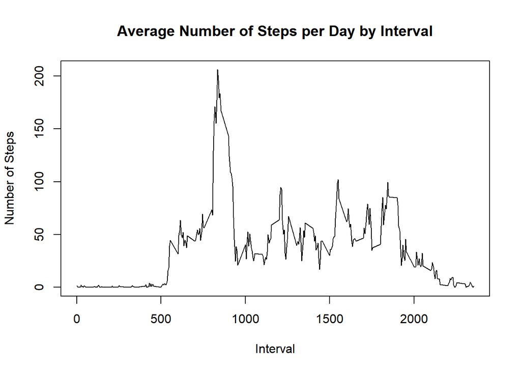

```r
steps_by_interval <- aggregate(steps ~ interval, week2, mean)
plot(steps_by_interval$interval,steps_by_interval$steps, type="l", xlab="Interval", ylab="Number of Steps",main="Average Number of Steps per Day by Interval")
```

5. The 5-minute interval that, on average, contains the maximum number of steps

```r
max_interval <- steps_by_interval[which.max(steps_by_interval$steps),1]
max_interval
```

```
## [1] 835
```

## Imputing missing values

6. Code to describe and show a strategy for imputing missing data

```r
NATotal <- sum(!complete.cases(week2))
NATotal
```

```
## [1] 2304
```

```r
StepsAverage <- aggregate(steps ~ interval, data = week2, FUN = mean)
fillNA <- numeric()
for (i in 1:nrow(week2)) {
    obs <- week2[i, ]
    if (is.na(obs$steps)) {
        steps <- subset(StepsAverage, interval == obs$interval)$steps
    } else {
        steps <- obs$steps
    }
    fillNA <- c(fillNA, steps)
}
```

```r
new_activity <- week2
new_activity$steps <- fillNA
```

7. Histogram of the total number of steps taken each day after missing values are imputed

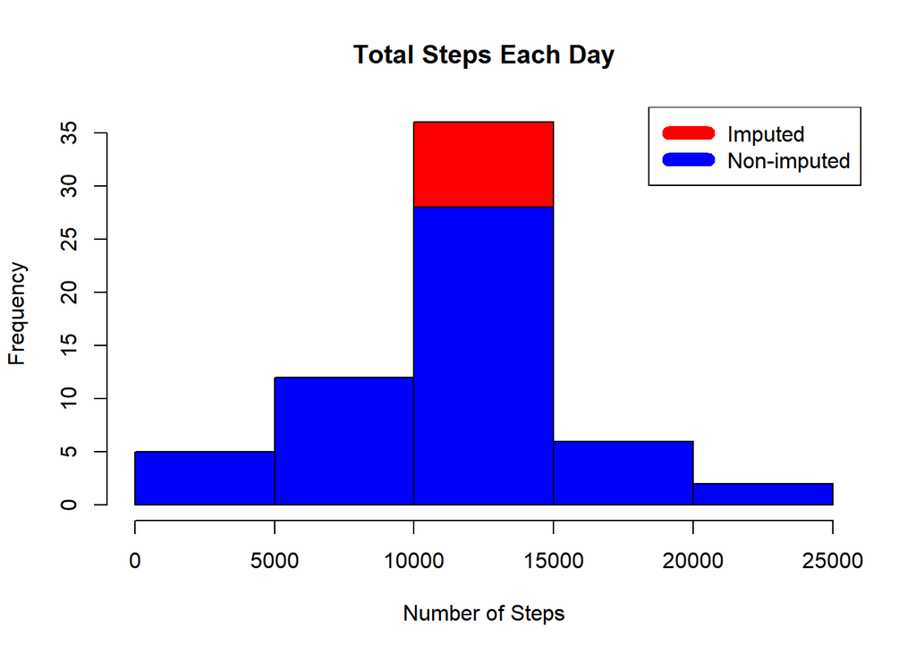

```r
StepsTotalUnion <- aggregate(steps ~ date, data = new_activity, sum, na.rm = TRUE)
hist(StepsTotalUnion$steps, main = paste("Total Steps Each Day"), col="red", xlab="Number of Steps")
#Create Histogram to show difference.
hist(steps_by_day$steps, main = paste("Total Steps Each Day"), col="blue", xlab="Number of Steps", add=T)
legend("topright", c("Imputed", "Non-imputed"), col=c("red", "blue"), lwd=10)
```

7a) Calculate and report the mean of total number of steps taken per day.

```r
rmeantotal <- mean(StepsTotalUnion$steps)
rmeantotal
```

```
## [1] 10766.19
```

7b) Calculate and report the median of total number of steps taken per day.

```r
rmediantotal <- median(StepsTotalUnion$steps)
rmediantotal
```

```
## [1] 10766.19
```

7c) Do these values differ from the estimates from the first part of the assignment? What is the impact of imputing missing data on the estimates of the total daily number of steps?

```r
rmediandiff <- rmediantotal - rmedian
rmediandiff
```

```
## [1] 1.188679
```

```r
rmeandiff <- rmeantotal - rmean
rmeandiff
```

```
## [1] 0
```

## Are there differences in activity patterns between weekdays and weekends?

8. Panel plot comparing the average number of steps taken per 5-minute interval across weekdays and weekends

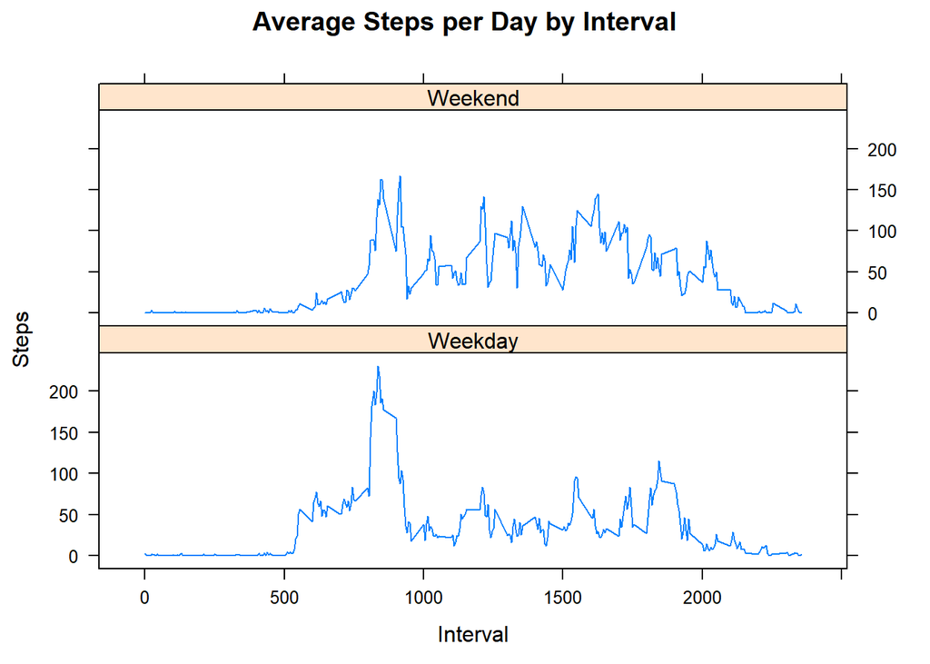

```r
weekdays <- c("Monday", "Tuesday", "Wednesday", "Thursday",
              "Friday")
new_activity$dow = as.factor(ifelse(is.element(weekdays(as.Date(new_activity$date)),weekdays), "Weekday", "Weekend"))
StepsTotalUnion <- aggregate(steps ~ interval + dow, new_activity, mean)
library(lattice)
xyplot(StepsTotalUnion$steps ~ StepsTotalUnion$interval|StepsTotalUnion$dow, main="Average Steps per Day by Interval",xlab="Interval", ylab="Steps",layout=c(1,2), type="l")
```